# Lab 15 WADDS

WADDS

May 2, 2018

## Team

The Question: North Korean leader Kim Jong-Un is very interested in increasing the overall happiness of the citizens of North Korea. As a world leader, he is interested in increasing the visibility and strength of North Korea, and happy citizens tend to signify stable and powerful countries. We have been hired to determine which factors increase the happiness of citizens, so that North Korea can improve their ranking.

We will be using data from the World Happiness Report to analyze which factors increase the overall happiness ranking of a country. The dataset can be found here, at this link: https://www.kaggle.com/unsdsn/world-happiness

```
##
## Call:
## lm(formula = Happiness.Score ~ Economy..GDP.per.Capita. + Family +
##     Health..Life.Expectancy. + Freedom + Generosity + Trust..Government.Corruption.,
##     data = happiness)
##
## Residuals:
##      Min       1Q   Median       3Q      Max
## -1.52798 -0.25219 -0.02277  0.28526  1.20417
##
## Coefficients:
##                               Estimate Std. Error t value Pr(>|t|)
## (Intercept)                     1.7430     0.1874   9.303  < 2e-16 ***
## Economy..GDP.per.Capita.        0.7844     0.2045   3.836 0.000185 ***
## Family                          1.1178     0.2021   5.532 1.40e-07 ***
## Health..Life.Expectancy.        1.2889     0.3215   4.009 9.65e-05 ***
## Freedom                         1.4757     0.3425   4.309 2.98e-05 ***
## Generosity                      0.3807     0.3293   1.156 0.249524
## Trust..Government.Corruption.   0.8266     0.4843   1.707 0.089975 .
## ---
## Signif. codes:  0 '***' 0.001 '**' 0.01 '*' 0.05 '.' 0.1 ' ' 1
##
## Residual standard error: 0.4998 on 148 degrees of freedom
## Multiple R-squared:  0.8124, Adjusted R-squared:  0.8048
## F-statistic: 106.8 on 6 and 148 DF,  p-value: < 2.2e-16
```

The linear model describing happiness of a country is given by the equation:

$$Y_{happiness}=1.74+0.78x_{GDP}+1.12x_{fam}+1.29x_{heatlh}+1.48x_{free}+0.38x_{gen}+0.83x_{trust}$$

This means that for every unit increase in the economy variable, there will be an average increase in 0.78 on the happiness score when all else is held fixed. For every unit increase of the family variable, there will be an average of a 1.12 increase in the happiness score. For every unit increase in the health variable, the happiness score will increase by 1.29 on average. For every unit increase in freedom, there is an average of a 1.48 increase in the happiness score. For every unit increase in generosity, there is an average of a 0.38 increase in happiness score, and finally, for every unit increase in trust in the government, there is an average of a 0.83 increase in the happiness score when all else is held fixed. From our model, we see that 81.24 percent of the variation on global happiness can be explained by our linear model.

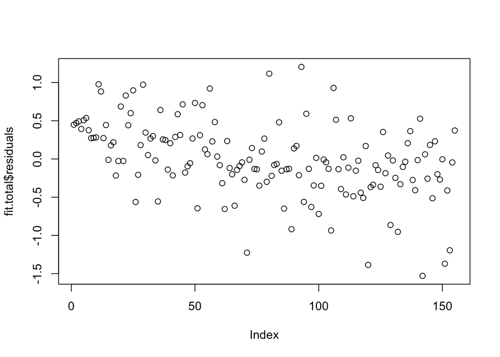

Reflection: Our goal for this semester is to learn how to use R to solve problems in a data science team setting. We hope to learn how to effectively communicate results and processes so we can analyze the world around us.

As a team, we feel we were able to work well in a group setting. We always found time to meet on Thursday nights to put all of our individual contributions together. We were always on time and worked well on the team parts together. As a team, we pulled together consistent and in-depth reports on our findings. And we feel we learned how to effectively communicate the results of our analysis each week.

If we could travel back in time, we would tell our team to keep meeting every single week, and showing up on time. We should also keep reading the modules and coming to class prepared to contribute to the team tests. We would also tell ourselves to stop working individually on the team application excercises, and start acting more collaboratively on the in-class activities. We would also tell ourselves to start discussing the readings before taking the tests, so we could help each other work through any misunderstandings so we all have a greater understanding of the material.

## Sarah

Freedom and Happiness

In this section, we will analyze how freedom will affect a general country’s happiness. The freedom category of the dataset represents the extent to which freedom contributed to the overall happiness score of the country.

First we will use a permuation hypothesis test to see if there was a significant difference in the freedom contribution for the ten happiest countries. This is done by taking a thousand random samples of the average of ten freedom contributions, and comparing the mean of the top ten with this distribution overall.

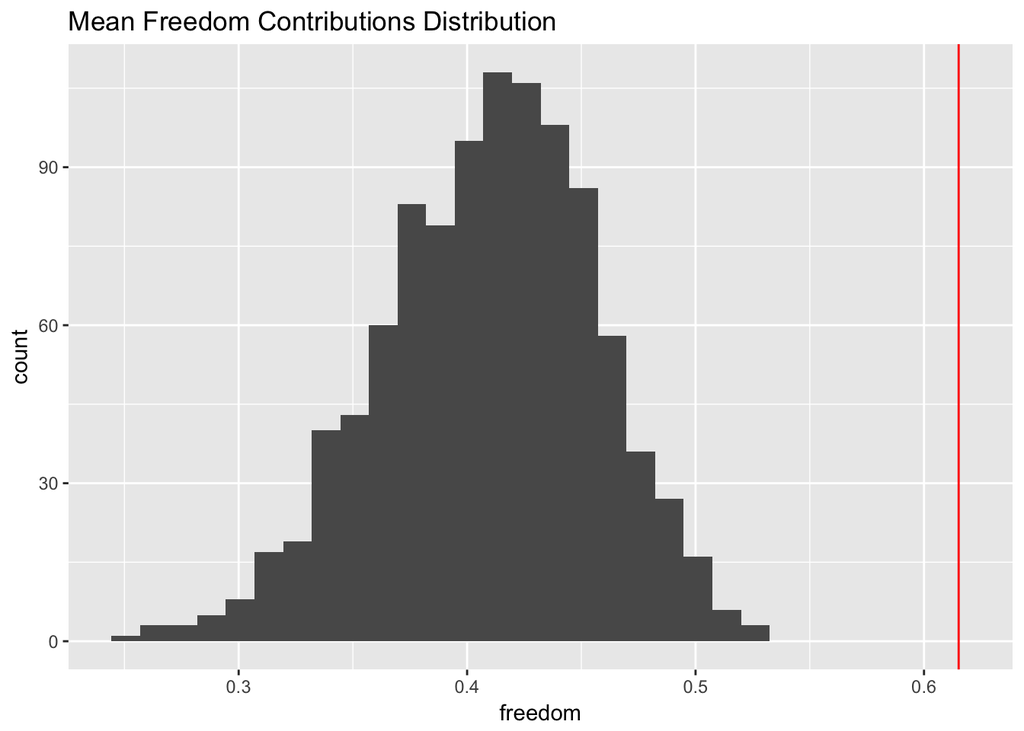

```
## [1] 1
```

As one can see, there is indeed a significant difference between the freedom contribution in the top ten happiest countries and the rest of the countries. This suggests that freedom has a significant impact on a country’s happiness.

To further this analysis, we will perform linear regression on the relationship between the freedom contribution and the happiness scores for each country.

```
##
## Call:
## lm(formula = Happiness.Score ~ Freedom, data = happiness)
##
## Residuals:
##      Min       1Q   Median       3Q      Max
## -2.62713 -0.66167  0.08347  0.78087  1.87101
##
## Coefficients:
##             Estimate Std. Error t value Pr(>|t|)
## (Intercept)   3.5963     0.2180  16.495  < 2e-16 ***
## Freedom       4.2998     0.5009   8.584 9.69e-15 ***
## ---
## Signif. codes:  0 '***' 0.001 '**' 0.01 '*' 0.05 '.' 0.1 ' ' 1
##
## Residual standard error: 0.9324 on 153 degrees of freedom
## Multiple R-squared:  0.3251, Adjusted R-squared:  0.3206
## F-statistic: 73.69 on 1 and 153 DF,  p-value: 9.688e-15
```

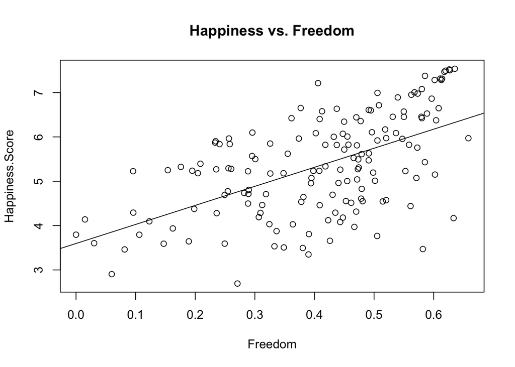

The linear model suggests that for every unit increase in the freedom contribution, the happiness score will increase by 4.3 on average, and that a country with no freedom contribution will have an estimated happiness score of 3.596. Both these pieces of the linear model are significant. However, this linear model only accounts for 32.5% of the variation in the happiness scores, so we will examine other factors as well.

Goal Reflection

The goals I set for myself for six months and five years after graduation haven’t really changed all that much with this semester. I still am hoping to graduate next year with a major in math and a focus in data science and statistics, along with a minor in creative writing. After that, I still hope to be exploring a variety of jobs or projects within jobs and getting a feel for what I might like. I also might consider getting a Masters after I get a little more experience in industry to get a better feel for what really makes me happy. I have an internship working with data this summer, and I’m hoping that will really help me solidify some goals as well.

## Abby

Linear Modeling:

The Question: Does generosity increase happiness? The World Happiness Report combines observational data from citizens of 155 countries each year to determine which factors increase the overall happiness of the people living in each country. Generosity is a measure of the amount of people in a given country who regularly give to charity. Generally, it seems generosity would positively impact happiness, as helping others increases our perceptions of self-worth and gives people the satisfication of knowing they have made a difference in the lives of other people. We would therefore expect a linear model analyzing the effect of generosity on happiness to indicate an increase in happiness with increasing generosity scores.

```
##
## Call:
## lm(formula = Happiness.Score ~ Generosity, data = WHR2)
##
## Coefficients:
## (Intercept)   Generosity
##       5.032        1.303
```

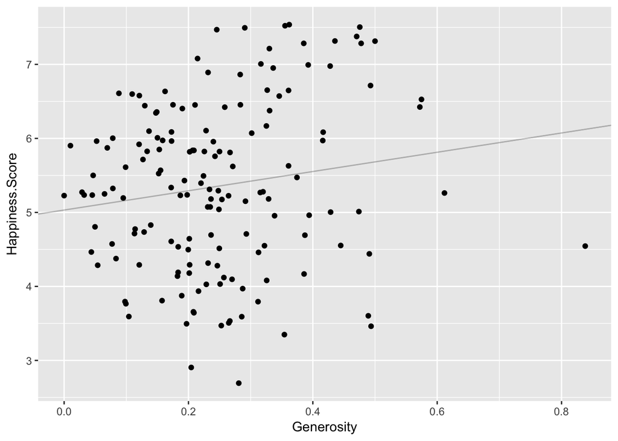

```
##
##  Pearson's product-moment correlation
##
## data:  WHR2$Generosity and WHR2$Happiness.Score
## t = 1.944, df = 153, p-value = 0.05373
## alternative hypothesis: true correlation is not equal to 0
## 95 percent confidence interval:
##  -0.002452421  0.305428466
## sample estimates:
##       cor
## 0.1552558
```

The linear model fitting Happiness Scores on Generosity gives us the equation y = 1.303x + 5.032. With a slope of 1.303, we can see that generosity seems to have a slightly positive effect on the happiness Score of a country. However, looking at the model visually, the correlation between generosity and happiness Scores does not seem to be very high. Testing for the correlation between generosity and happiness gives us a correlation of 0.155, which indicates a weak positive correlation between generosity and happiness scores. Taking a look at the residuals, we may be able to determine if there are possibly other confounding variables which may impact happiness.

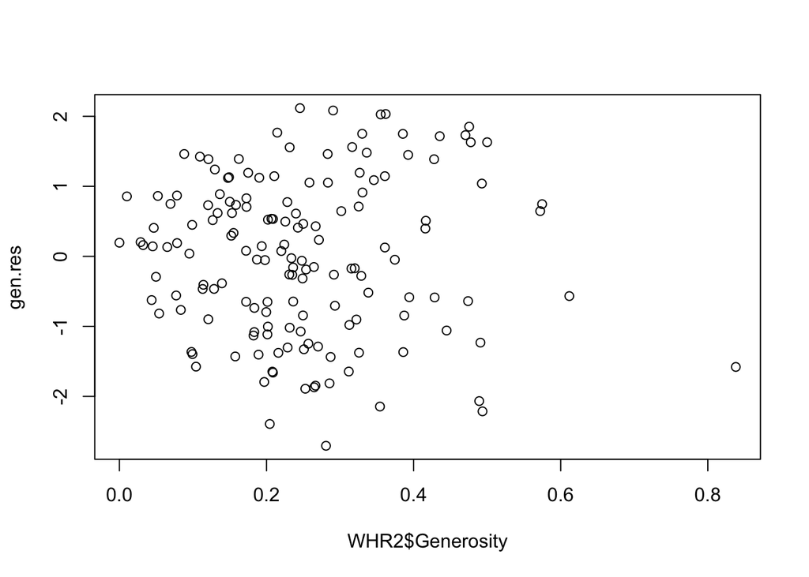

Looking at the plot of the residuals, we can see there is no real pattern to the residuals, this indicates that a linear model is appropriate for this data. From the analysis above, we can see that the correlation between generosity and happiness are weakly correlated. From the plot above, however, we can also see that the linear model generated from the data is appropriate. This simply indicates that generosity does not seem to increase the overall happiness of a country’s citizens, but it is still possible that generosity could impact other variables within the data set, such as health or trust in the government, which may have a stronger correlation with happiness.

Semester Reflection:

Before this class, my 6-month post-graduation goal was to be working for a larger tech company, such as HP or Intel. This plan has remained unchanged, but has been made more realistic through the course of this semester. Because of the skills I have gained through my Computer Science and statistics courses at CU, I have been offered a position as a Data Science intern at HP, where I will be working this summer. This internship is guaranteed for the duration of my time in higher education, and I have informed that most interns receive job offers upon graduation, making my 6-month goal easily attainable through hard work both this summer and any subsequent summers I decide to spend at HP.

My five year goals have also remained relatively stable, yet I do feel I have broadened my definition of what data analysis I would consider valuable to society. My work at HP will involve analyzing the likelihood of certain risks happening at various HP locations, which will increase the safety of those working there and prove to be extremely valuable information.

In this course I learned how to visual data in a more effective and clear way. Often, it is hard to decide the best methods and practices to use in modeling data, and showing trends. I feel it has also been very helpful in hypothesis testing, as it adds a nice visual which clearly illustrates how the results of a hypothesis test inform our understanding of the data. If I were to give advice to myself at the beginning of the semester, I would have suggested looking for more outside resources to learn the material. There are plenty of professors I have taken in the past with notes I could have asked for to just clear some stuff up when it comes to R, since I struggled trying to learn it through the textbook. I would suggest that I keep staying on top of my work and getting it done before our team meets to pull all of our individual parts together. Being organized helped our team successfully complete our labs without taking too much time out of our schedules. If I were to tell myself to stop doing something, it would be to stop trying to figure out the individual assignments without studying the concepts further when I am lost.

## David

**Distributions of Happiness Score and Trust Governmen Corruption**

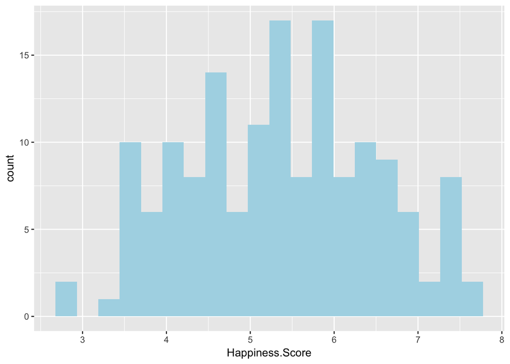

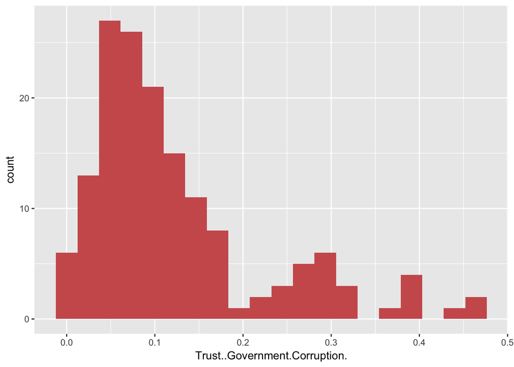

The histograms shows that the distribution of Happiness Score of the 155 countries appears to be symmetric and approximate normal while the distribution of Trust Governmen Corruption of the 155 countries is seriously right-skewed. It means that the happiness score follows normal distribution but the Trust Governmen Corruption has large proportion of low scores which means lots of countries people do not trust Governmen Corruption.

**Correlation between Happiness Score and Trust Governmen Corruption**

Now use Correlation test, the hypotheses are:

$H0: \rho = 0$ vs. $H1: \rho \neq 0$

```
##
##  Pearson's product-moment correlation
##
## data:  data$Trust..Government.Corruption. and data$Happiness.Score
## t = 5.8758, df = 153, p-value = 2.538e-08
## alternative hypothesis: true correlation is not equal to 0
## 95 percent confidence interval:
##  0.2911242 0.5495541
## sample estimates:
##       cor
## 0.4290797
```

We test the correlation between the Happiness Score and Trust Governmen Corruption, the p value of the test isclose to 0 so that we should reject the H0 null hypothesis and conclude H1 that there is significant correlation between the Happiness Score and Trust Governmen Corruption at 5% level.

**Linear regression of the Happiness Score and Trust Governmen Corruption**

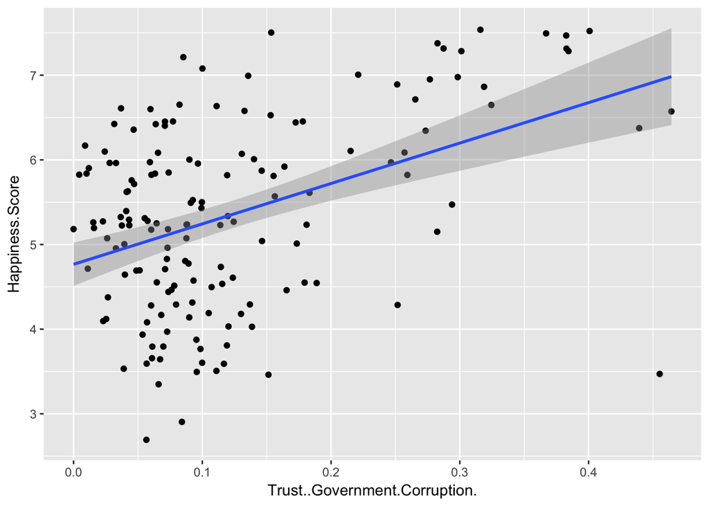

```
##
## Call:
## lm(formula = Happiness.Score ~ Trust..Government.Corruption.,
##     data = data)
##
## Residuals:
##     Min      1Q  Median      3Q     Max
## -3.4687 -0.7705  0.1210  0.7813  2.0398
##
## Coefficients:
##                               Estimate Std. Error t value Pr(>|t|)
## (Intercept)                     4.7662     0.1296  36.784  < 2e-16 ***
## Trust..Government.Corruption.   4.7746     0.8126   5.876 2.54e-08 ***
## ---
## Signif. codes:  0 '***' 0.001 '**' 0.01 '*' 0.05 '.' 0.1 ' ' 1
##
## Residual standard error: 1.025 on 153 degrees of freedom
## Multiple R-squared:  0.1841, Adjusted R-squared:  0.1788
## F-statistic: 34.53 on 1 and 153 DF,  p-value: 2.538e-08
```

The linear regression model shows significant relation between happiness score and Trust Government Corruption, we can find that there is clearly ascend trend in the plot that with increasing of the Trust Government Corruption there would also increase in the happiness score. The summary output shows 1 addtional score in Trust Government Corruption is associated with 4.7746 increase in happiness score.

If I could travel back, I would discuss more with my teammates and finish my work on time. Six month after graduation, I still plan to attend graduate school and I will be majoring statistics, during this time, I should have finished 1st semester graduate study. I also have some understanding about statistics (at least for some programming skills in R). After five years, I should finish my graduate study and work in the company. In the future, I plan to do some work relate to statistics and apply my knowledge into real life, help people solve problems. Actually these goals does not change, at least in couple of years.

From this course I have learnt so many techniques to deal with data analysis problem by R. Compared with a lot of languages I have learnt here. I feel that R is one of the most easiest language, and it’s actually a very powerful language used in Data Analysis. Although it is difficult for us to choose to best method to solve a single data science problem. It’s very important for me to learn deeply so we could train ourself to solve more complex problems. If time traveled to the beginning of the semester. I would tell myself I could communicate with our teammates often, and read more books in order to prepare me for the class well. I would keep contributing my ideas and help my teammates to finish labs and projects. If I were tell myself to stop doing something, it would be like following: just stay here and do my work and submit! Be an activte person!

## Derek

```r
library(corrplot)
happiness <- read_csv("~/Downloads/2017.csv")
other <- read_csv("~/Downloads/2016.csv") # I grab the older 2016 data because it also includes the region for each country
other <- other[,1:2]
drops <- c('Happiness.Rank', 'Whisker.high', 'Whisker.low') # Drop uneeded columns
happiness <- happiness[ , !(names(happiness) %in% drops)]
happiness <- left_join(happiness, other, by="Country")
happiness$Country<-as.factor(happiness$Country)
# Filling in some missing data
happiness[happiness$Country == "Taiwan Province of China" ,10] <- "Eastern Asia"
happiness[happiness$Country == "Hong Kong S.A.R., China" ,10] <- "Eastern Asia"
happiness[happiness$Country == "Central African Republic" ,10] <- "Sub-Saharan Africa"
happiness[happiness$Country == "Mozambique" ,10] <- "Sub-Saharan Africa"
happiness[happiness$Country == "Lesotho" ,10] <- "Sub-Saharan Africa"
happiness$Region<-as.factor(happiness$Region)
```

I looked at whether the linear model is consistent across all types of contries. To seperate the countries into “types” I clustered them with kmeans based on the values *Family*, *Health..Life.Expectancy.*, *Freedom*, *Economy..GDP.per.Capita.*, *Generosity*, and *Trust..Government.Corruption.* into three clusters. So countries that are similar to each other will be catogrized the same. We end up with three groups that can be loosely thought of as 1st world countries, 3rd world countries and the countries inbetween. I plot these clusters with a sum of the statistics on the x-axis and Happiness.Score on the the y-axis and can see a nice positive linear relationship. We can also see that the clustering worked because we would expect countries that have similar scores to have similar happiness.

```
##  [1] 5.260052 5.208127 5.180989 5.217650 5.039021 5.082116 5.129123
##  [8] 5.267545 5.186147 5.218834 4.411390 4.867670 4.774425 5.203077
## [15] 4.934907 4.766803 5.243260 5.009822 4.142135 4.913329 4.156937
## [22] 5.355699 4.970199 4.281555 4.144665 4.435653 4.384837 4.295832
## [29] 4.475278 5.229065 4.278248 4.114460 4.464544 3.999759 4.431113
## [36] 4.079121 4.175091 4.150403 4.556688 3.958046 4.033668 4.261265
## [43] 4.444907 3.999620 4.253990 4.916896 4.087499
```

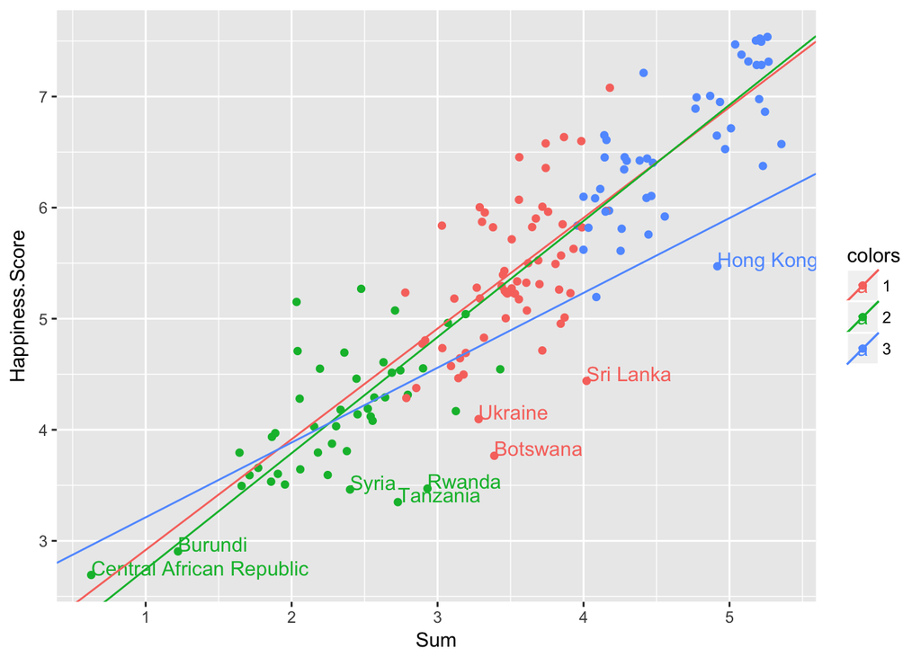

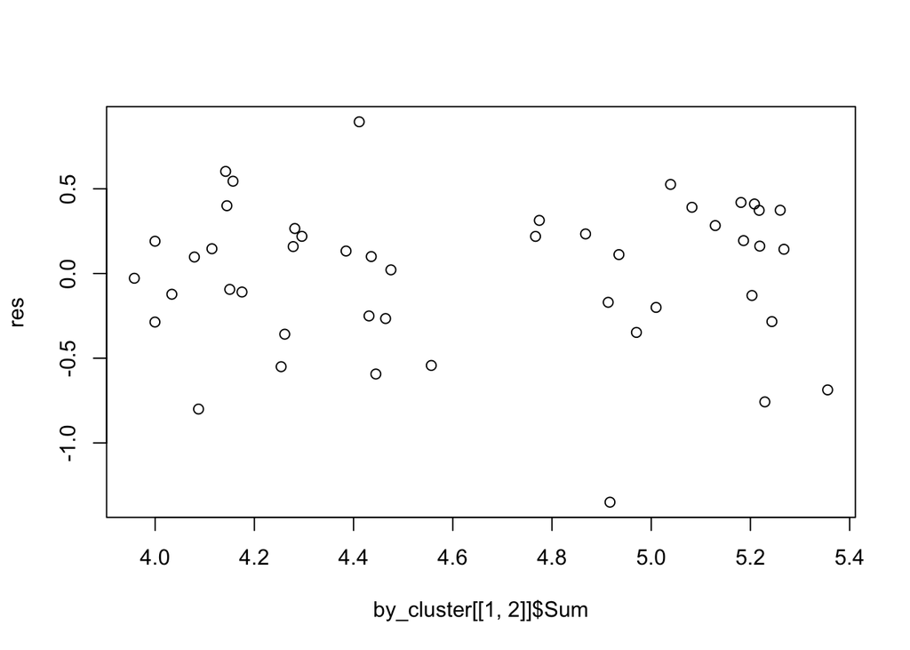

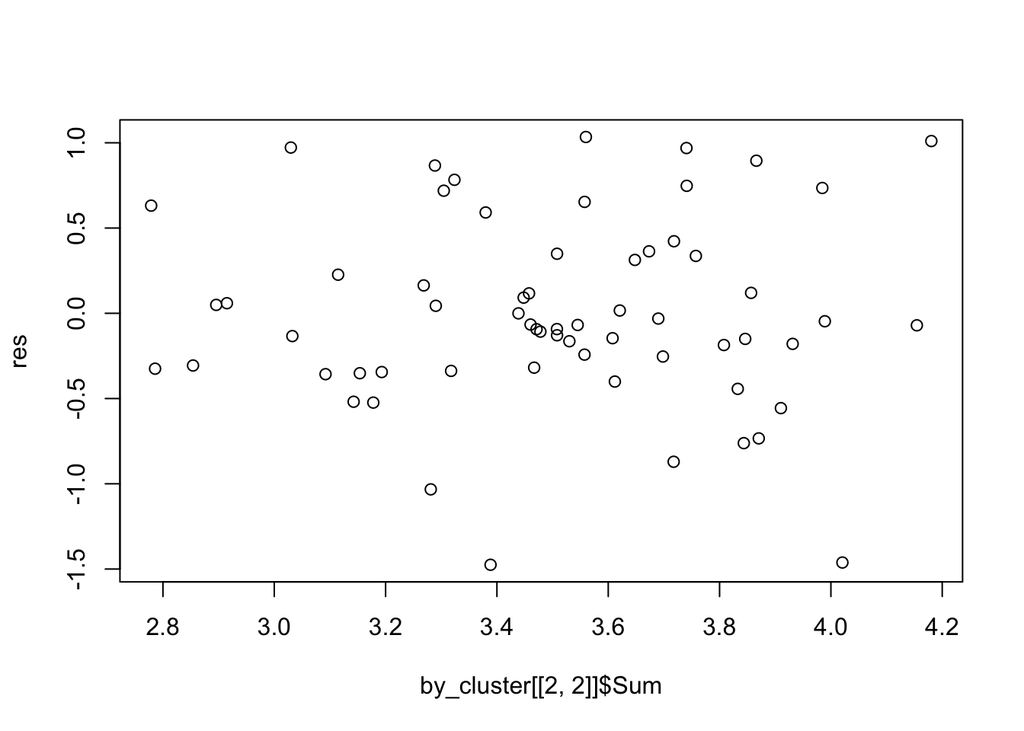

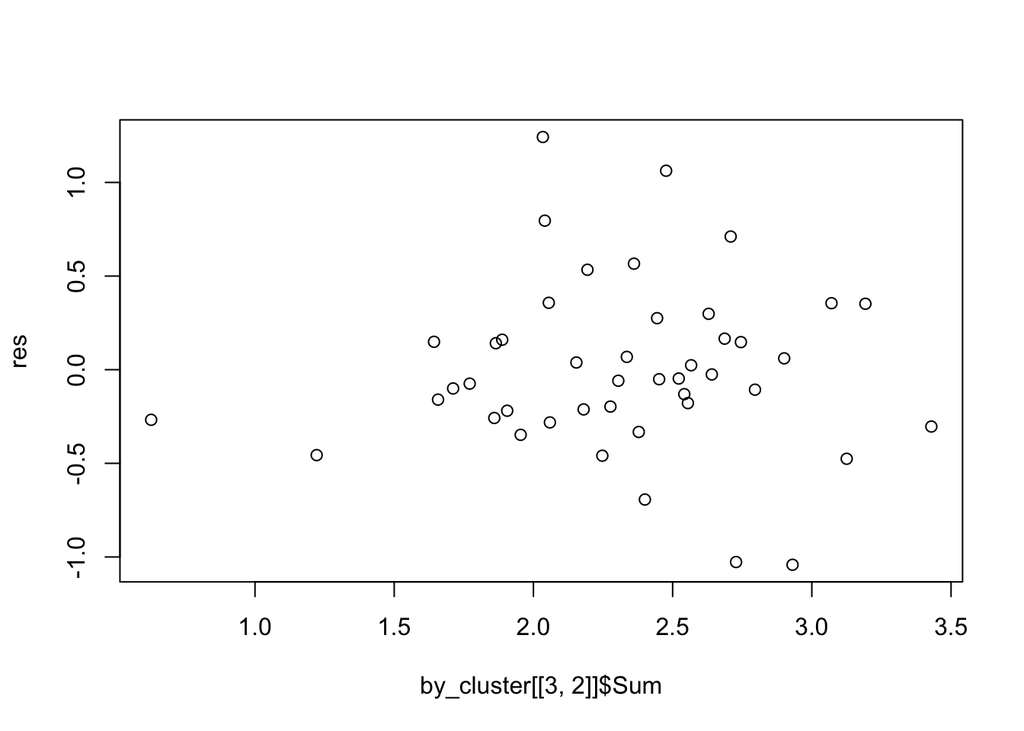

Reflection: I havent changed my goals that I had from the begining of the semester. However over the course of the semester I have learned R and some useful data processing techniques I look forward to applying these techniques in future data related classes. If I could give myself advice at the beginning of the semester I would tell myself to focus more on time management.

## Will

GDP per Capita

In this section, we will discussion whether GDP per Capita has a significant influence in Happiness Score.

This question is interesting and important. If there is a strong positive and significant association between happiness and GDP per Capita, each government’s budgeting, focus and priority will and should shift over all the world.

At the early stage, when we try to study this kind of question, the most efficient way is to load the dataset and then draw one or more plots, sometimes this method will inspire us. But only if we combine the heuristic approach like visualization with some formal tool (such as *hypothesis test* and *linear regression*) can we discover the hidden pattern. The new learned toolkit is powerful and elegant.

Hypothesis Test Approach First, we try to figure out whether happiness score has a significant change when GDP per capita moves from 1 unit below to the above.

```
## [1] 1.540446
```

We assume that no matter GDP per Capita is above or below, the happiness scores are almost the same. It is our null hypothesis. To test the hypothesis, we mix up the GDP per capita labels. Then we will compare the stimulated statistics with the observed one.

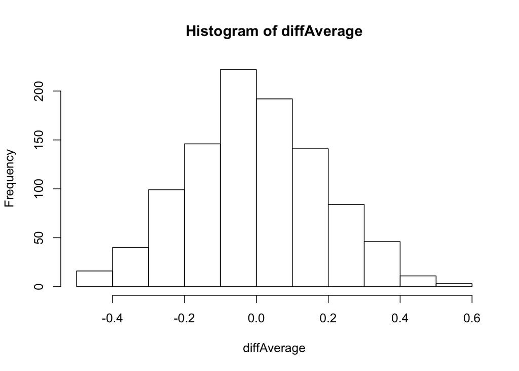

```r
# Mix up the GDP labels
N = 75
diffAverage <- replicate(1000, {
    all <- sample(c(scoreHappiness_above,scoreHappiness_below))
    testGroup1 <- all[1:N]
    testGroup2 <- all[(N+1):(2*N)]
  return(mean(testGroup2) - mean(testGroup1))
})
hist(diffAverage)
abline(v=obsDiff, col="red", lwd=2)
```

```r
# Find the percentile
percentile <- ecdf(diffAverage)
percentile(obsDiff)
```

```
## [1] 1
```

Linear Regression Approach

Now we study the happiness-GDP association problem by using linear regression

```r
happyGDP_model <- lm(Happiness.Score ~ Economy..GDP.per.Capita., data = WorldHappiness2017)
summary(happyGDP_model)
```

```
##
## Call:
## lm(formula = Happiness.Score ~ Economy..GDP.per.Capita., data = WorldHappiness2017)
##
## Residuals:
##      Min       1Q   Median       3Q      Max
## -1.88807 -0.45200 -0.05328  0.49425  1.89833
##
## Coefficients:
##                          Estimate Std. Error t value Pr(>|t|)
## (Intercept)                3.2032     0.1356   23.62   <2e-16 ***
## Economy..GDP.per.Capita.   2.1842     0.1267   17.24   <2e-16 ***
## ---
## Signif. codes:  0 '***' 0.001 '**' 0.01 '*' 0.05 '.' 0.1 ' ' 1
##
## Residual standard error: 0.6617 on 153 degrees of freedom
## Multiple R-squared:  0.6601, Adjusted R-squared:  0.6579
## F-statistic: 297.1 on 1 and 153 DF,  p-value: < 2.2e-16
```

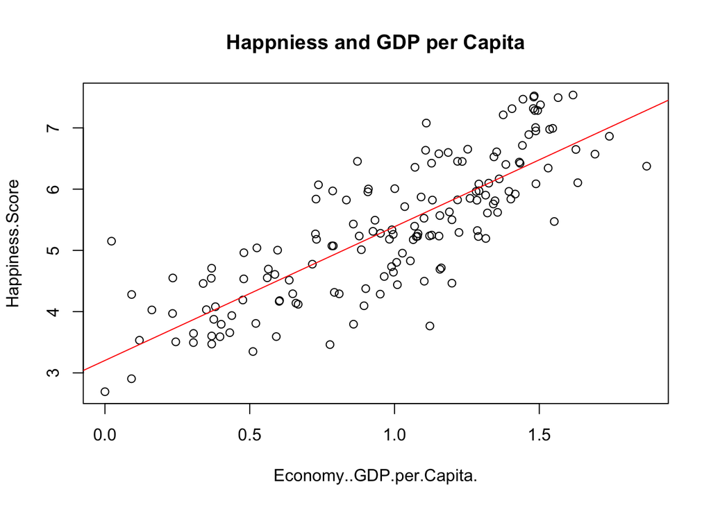

```r
plot(Happiness.Score ~ Economy..GDP.per.Capita., data = WorldHappiness2017, main="Happniess and GDP per Capita")

## find the regression line
interceptHappy <- coef(summary(happyGDP_model))["(Intercept)",1]
slopeHappy <- coef(summary(happyGDP_model))["Economy..GDP.per.Capita.",1]
abline(a = interceptHappy, b = slopeHappy, col="red")
```

We can conclude that happiness of different country and GDP per Capita has as a significantly positive association. Here we use two different formal tools, we have a strong confidance about the conlusion.

Reflection on Lab 2 William Blake once wrote:

> “To see a World in a Grain of Sand And a Heaven in a Wild Flower, Hold Infinity in the palm of your hand And Eternity in an hour.”

I have not changed my wish to apply machine learning/deep learning tools to real world such as *finance*.

Technique such as programming and statistical thinking have no meaning if we don’t have any human understanding. The various data analyzed in computer science are standard or would put in a standard way. At the same time, it means that the data is too “thin” to make a difference. But our intuitions are always mis-guiding. We need the tools just as the ones we pick up from this course the filter the confused and wrong intuitions.

This is the first big lesion I learned from the course. Secondly, in the course and other studies, I find that more supplicated techniques and tricks are already hide in the relatively easier and thighward tools learned in this lesson. In the reflection, I am very thankful to take in the course. And I want to explore more and go far away from the origin by combining the “standardization” computer thinking and our sense-making of “thick” data.

## Summary of Individual Contributions

Sarah: I used permutation hypothesis testing to analyze whether there was a significant difference in the mean of the ten happiest countries’ freedom contribution as compared with the rest of the data. I also used linear regression to determine the relationship between freedom and happiness. Finally, I reflected on the goals I set for myself during the beginning of the semester.

Abby: I analyzed generosity and happiness to see if increased generosity lead to an increase in overall happiness for citizens of different countries. By creating a linear model, I saw there was a slightly positive correlation between generosity and happiness, but the linear model did not fit the data very well. I then created a residual plot to see if it was possible that a confounding variable would have made a linear model inappropriate. Through my analysis of the residual plot I concluded that while the linear model did not fit the data well, it was still an appropriate model. For out team part, I found the dataset we wanted to use, described our overall question and why it was important, and contributed to the analysis of our linear model. I also ploted the residuals to make sure our linear model was not being impacted by confounding variables. Finally, I reflected on this last semester and how this class has impacted me.

David: In this lab I have analyzed hapiness score and trust government corruption in the given data using linear regression, and I have used linear regression model significant relation between happiness score and Trust Government Corruption. I have also made historgram to shows that the distribution of Happiness Score of the 155 countries appears to be symmetric and approximate normal. Also I reflected what I have done for this semester and how this class affect my future career

Will: For lab15, I try to discuss is whether GDP per Capital has a significant influence in Happiness Score. In order to analyze this question, I used the Null Hypothesis to figure out, whether it has statistics significant to show relationship between these two variables. Finally, happiness of different country and GDP per Capita has as a significantly positive association.